# Diagonal Case - Multiple Stocks/Ages

## 5.3 The output from the fit

Here is the fitted spline curve to the number of unmarked fish available of both stocks and ages.

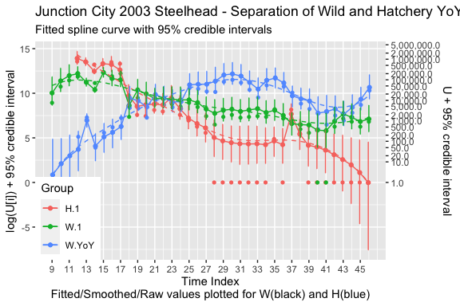

Fitted spline curve

```r
demo3.fit$plots$fit.plot
```

The separation of wild and hatchery fish is evident as well has the start of the spline for the hatchery fish.

A plot of the $logit(P)$ is

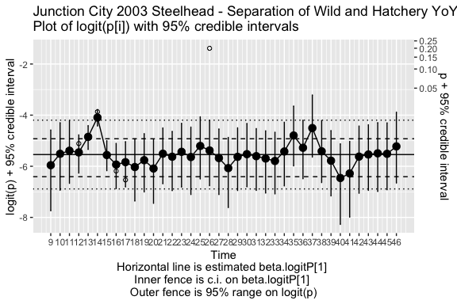

Estimates of logit(p)

```r
demo3.fit$plots$logitP.plot
```

In cases where there is no information (such as the first julian week), $BTSPAS$ has interpolated based on the distribution of catchability in the other strata and so the credible interval is very wide.

A summary of the posterior for each parameter is also available. In particular, here are the summary statistics on the posterior sample for the total number unmarked separated by wild and hatchery origin and the different ages:

```r
demo3.fit$summary[ grepl("Utot", row.names(demo3.fit$summary)),]
```

```
#>               mean        sd      2.5%     25%     50%     75%    97.5%     Rhat n.eff
#> Utot       6898903 1832665.1 4375291.6 5650086 6524989 7644093 12032087 1.078609    34
#> Utot.H.1   3875433  829188.6 2589298.5 3276220 3757773 4341926  5844094 1.150846    20
#> Utot.W.1   1348184  420103.9  800107.3 1073633 1260605 1514400  2424269 1.057564    46
#> Utot.W.YoY 1675286  891964.8  772846.3 1145625 1423931 1861434  4504528 1.014674   140
```

# 6 References

Bonner, S. J., & Schwarz, C. J. (2011). Smoothing population size estimates for Time-Stratified Mark–Recapture experiments Using Bayesian P-Splines. Biometrics, 67, 1498–1507. https://doi.org/10.1111/j.1541-0420.2011.01599.x

Schwarz, C. J., & Dempson, J. B. (1994). Mark-recapture estimation of a salmon smolt population. Biometrics, 50, 98–108.